# Assignment3

## 4.37

We first convert records to speeds measured in m/s, which is what we have done before in Ex 1.18

*We need to modify “KOR, S” to “KOR(S)” and do the similar for “KOR, N” to ensure that the data can be properly imported.*

```r
X0 <- read.table('T1-9.dat', row.names = 1)
head(X0)
```

```
##        V2    V3    V4   V5   V6   V7     V8
## ARG 11.57 22.94 52.50 2.05 4.25 9.19 150.32
## AUS 11.12 22.23 48.63 1.98 4.02 8.63 143.51
## AUT 11.15 22.70 50.62 1.94 4.05 8.78 154.35
## BEL 11.14 22.48 51.45 1.97 4.08 8.82 143.05
## BER 11.46 23.05 53.30 2.07 4.29 9.81 174.18
## BRA 11.17 22.60 50.62 1.97 4.17 9.04 147.41
```

```r
n <- nrow(X0) # sample sizes

scale <- c(100, 200, 400, 800 / 60, 1500 / 60, 3000 / 60, 42195 / 60) # scales
X <- as.data.frame(t(scale / t(X0))) # Element-wise division in R are done in terms of each column; transpose needed
head(X)
```

```
##           V2       V3       V4       V5       V6       V7       V8
## ARG 8.643042 8.718396 7.619048 6.504065 5.882353 5.440696 4.678353
## AUS 8.992806 8.996851 8.225375 6.734007 6.218905 5.793743 4.900355
## AUT 8.968610 8.810573 7.902015 6.872852 6.172840 5.694761 4.556203
## BEL 8.976661 8.896797 7.774538 6.768190 6.127451 5.668934 4.916113
## BER 8.726003 8.676790 7.504690 6.441224 5.827506 5.096840 4.037490
## BRA 8.952551 8.849558 7.902015 6.768190 5.995204 5.530973 4.770708
```

```r
meanX <- colMeans(X)
covX <- cov(X)
p <- ncol(X)
```

Construct qqplot and compute rqs

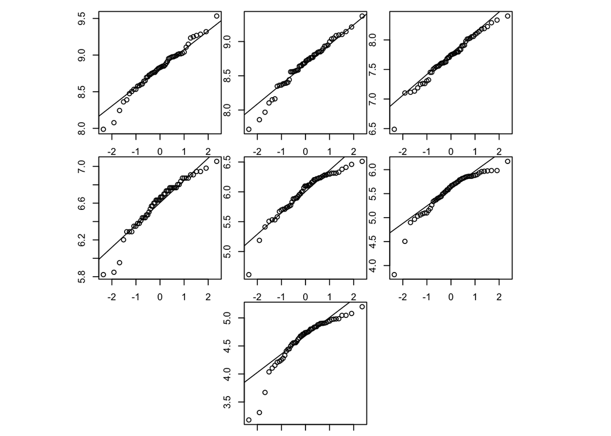

```r
plotqq <- function(col, title="") {
  qqp <- qqnorm(col, main = title)
  qqline(col)
  with(qqp, cor(x, y))
}
layout(matrix(c(1:6, 0, 7, 0), nrow = 3, byrow = TRUE), respect = TRUE)
par(mar = rep.int(1, 4))
rqs <- sapply(X, plotqq)
```

```r
rqs
```

```
##        V2        V3        V4        V5        V6        V7        V8
## 0.9897883 0.9858730 0.9845626 0.9665137 0.9474013 0.9300738 0.9221252
```

From rqs we conclude that first 4 variables have correlation coefficients for Q-Q plot greater than 0.965, while the last three have relatively low coefs. We believe the marginal normality of the first 4 variables while remain doubtful about that of the last 3.

Next we compute mahalanobis (generalized squared) distances and construct chi-square plot

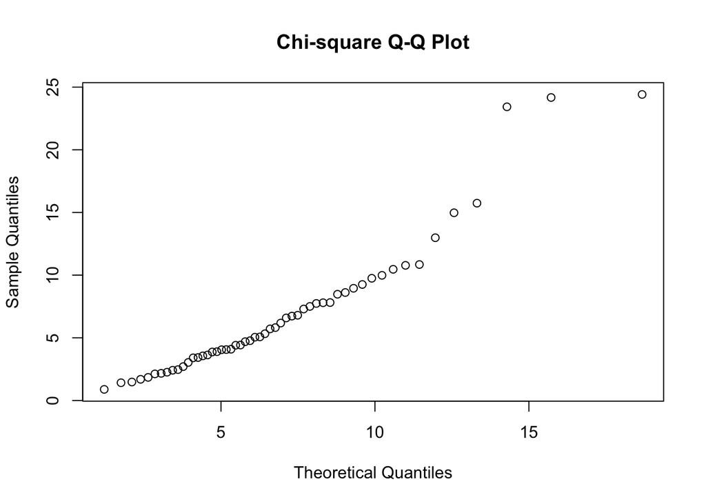

```r
squaredDist <- mahalanobis(X, meanX, covX)
qqplot(qchisq(ppoints(n, a = .5), df = p), squaredDist, main = "Chi-square Q-Q Plot", xlab = "Theoretical Quantiles", ylab = "Sample Quantiles")
```

```r
sum(squaredDist <= qchisq(.5, df = p)) / n # % of falling into first half
```

```
## [1] 0.5740741
```

We can see that roughly half of $d_j^2 \le q_{c,p}(.50)$ and that the chi-square plot is roughly a straight line with slope 1 passing through the origin (except for several outliers). Thus, we have due confidance over the multivariate normality of the data.

## 4.39

Import data

```r
X1_original <- read.table("T4-6.DAT")
X1 <- X1_original[1:5] # examine first 5 variables
head(X1)
```

```
##   V1 V2 V3 V4 V5
## 1 27 13 14 20 11
## 2 12 13 24 25  6
## 3 14 20 15 16  7
## 4 18 20 17 12  6
## 5  9 22 22 21  6
## 6 18 15 17 25  9
```

```r
meanX1 <- colMeans(X1)
covX1 <- cov(X1)
p1 <- ncol(X1)
n1 <- nrow(X1)
```

Construct qqplot and compute rqs

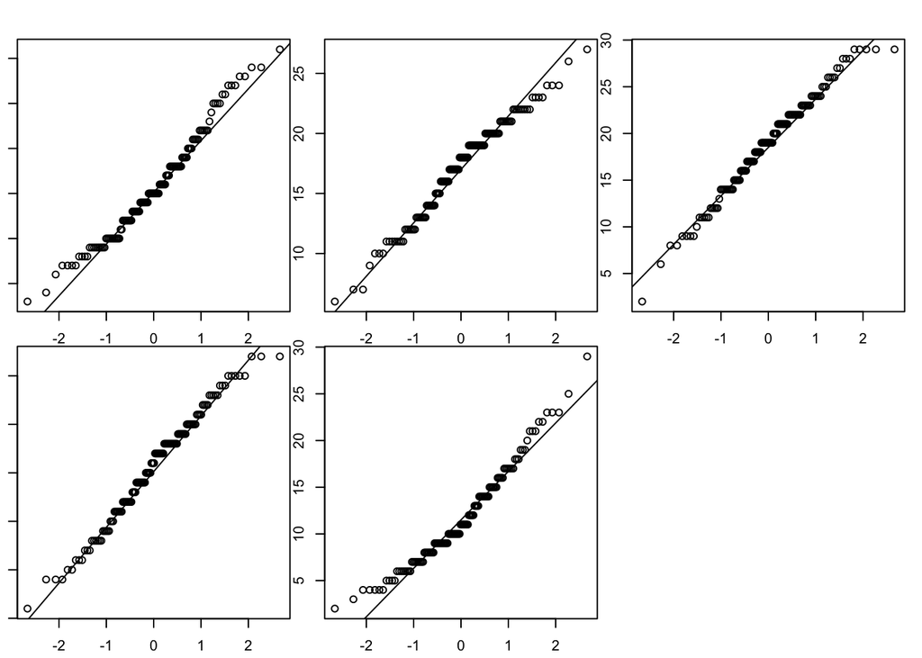

```r
layout(matrix(c(1:5, 0), nrow = 2, byrow = TRUE), respect = TRUE)
par(mar = rep.int(1, 4))
rqs1 <- sapply(X1, plotqq)
```

```r
rqs1
```

```
##        V1        V2        V3        V4        V5
## 0.9881301 0.9892880 0.9925086 0.9933800 0.9812888
```

We look up the table and find that the critical points for this test with $n=130$ and $\alpha=.05$ is around .989. Comparing this to rqs, we conclude that we doubt the marginal normality of the first and the last variable while others are fine.

Find the transformation

```r
require(car)
```

```r
bc1 <- powerTransform(X1[1])
lambda1 <- bc1$roundlam # optimal lamda
Y1 <- bcPower(X1[[1]], lambda1) # perform powerTransform

layout(matrix(c(1:2), nrow = 1, byrow = TRUE), respect = TRUE)
# before
plotqq(X1[[1]], "Before")
```

```
## [1] 0.9881301
```

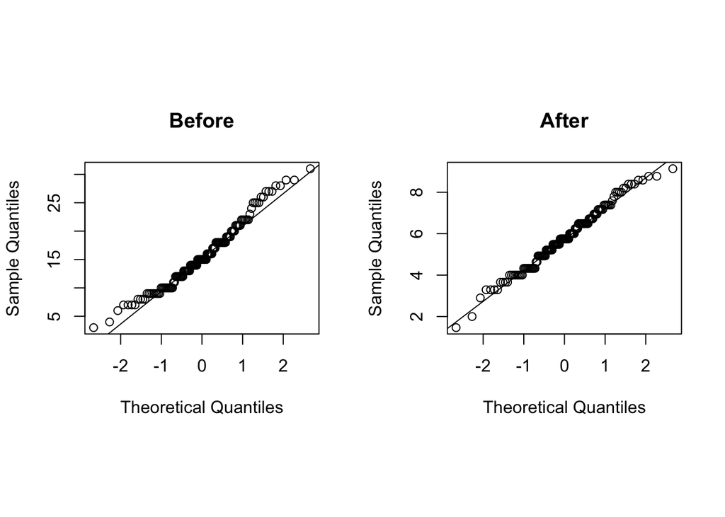

```
## [1] 0.9949123
```

```r
# after transformation
plotqq(Y1, "After")
```

```r
bc2 <- powerTransform(X1[5])
lambda2 <- bc2$roundlam # optimal lamda
Y2 <- bcPower(X1[[5]], lambda2) # perform powerTransform

layout(matrix(c(1:2), nrow = 1, byrow = TRUE), respect = TRUE)
# before
plotqq(X1[[5]], "Before")
```

```
## [1] 0.9812888
```

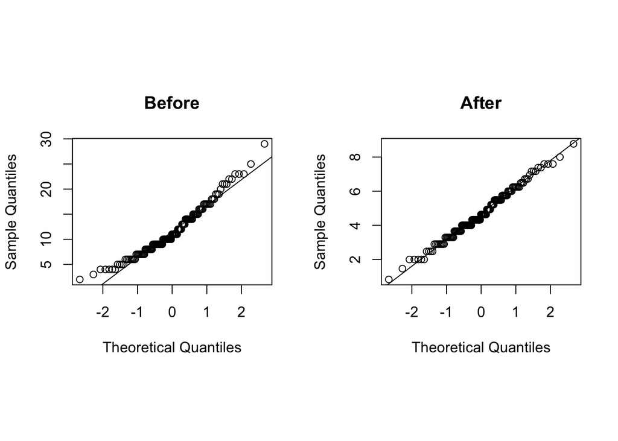

```
## [1] 0.9959115
```

```r
# after transformation
plotqq(Y2, "After")
```

We can see that after the box-cox transformation the Q-Q plots look much more like straigh lines. And the correlation coefficients rise up to around 0.995

Next we compute mahalanobis (generalized squared) distances and construct chi-square plot

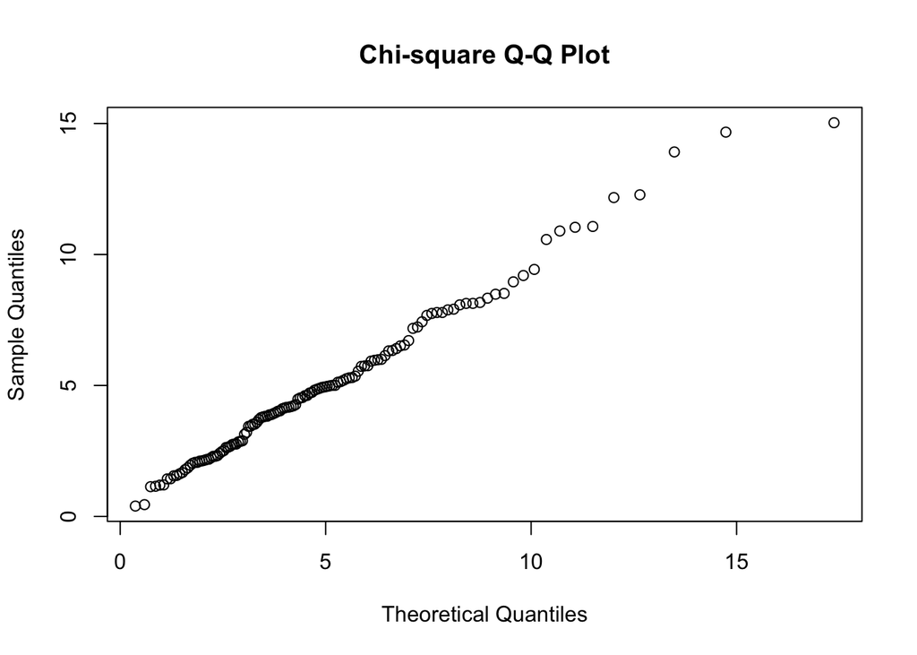

```r
squaredDist1 <- mahalanobis(X1, meanX1, covX1)
qqplot(qchisq(ppoints(n1, a = .5), df = p1), squaredDist1, main = "Chi-square Q-Q Plot", xlab = "Theoretical Quantiles", ylab = "Sample Quantiles")
```

```r
sum(squaredDist1 <= qchisq(.5, df = p1)) / n1 # % of falling into first half
```

```
## [1] 0.4923077
```

We can see that roughly half of $d_j^2 \le q_{c,p}(.50)$ and that the chi-square plot is roughly a straight line with slope 1 passing through the origin (except for several outliers). Thus, we have due confidance over the multivariate normality of the data.

## 5.4

Import data

```r
X2 <- read.table('T5-1.DAT', col.names = c("sweat_rate", "sodium", "potassium"))
meanX2 <- colMeans(X2)
n2 <- nrow(X2)
p2 <- ncol(X2)
covX2 <- cov(X2)
```

Compute 90% confidence ellipsoid

```r
eigensys1 <- eigen(covX2)
eigensys1$vectors # eigenvectors, i.e. axes of the ellipsoid
```

```
##             [,1]        [,2]        [,3]
## [1,] -0.05084144 -0.57370364  0.81748351
## [2,] -0.99828352  0.05302042 -0.02487655
## [3,]  0.02907156  0.81734508  0.57541452
```

```r
alpha = .1

fscale <- function(p, n, a) {
  p*(n-1)/(n-p)/n * qf(1-a, p, n-p)
} # compute scale for ellipsoid

axesLength <- sqrt(eigensys1$values * fscale(p2, n2, alpha))
axesLength # length of axes
```

```
## [1] 9.0506741 1.3607857 0.7292367
```

Consturct Q-Q plots and paired scatter plots

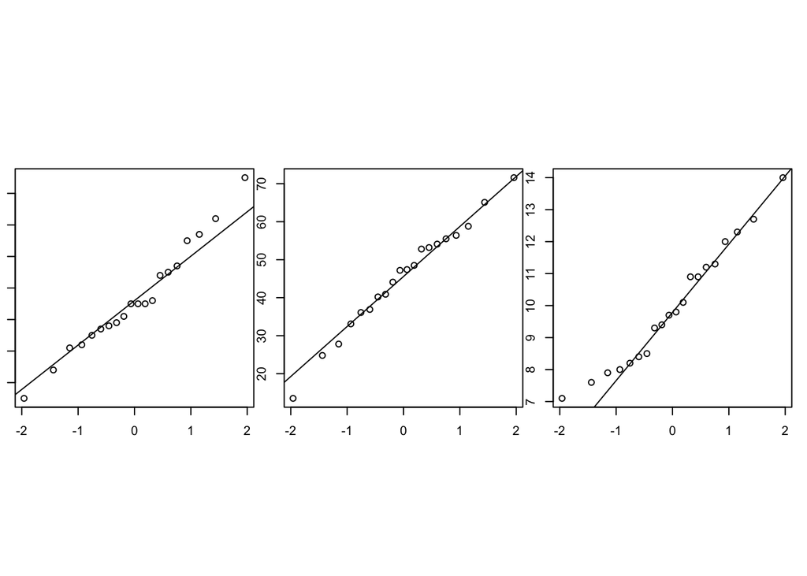

```r
layout(matrix(1:3, nrow = 1, byrow = TRUE), respect = TRUE)
par(mar = rep.int(1, 4))
rqs <- sapply(X2, plotqq)
```

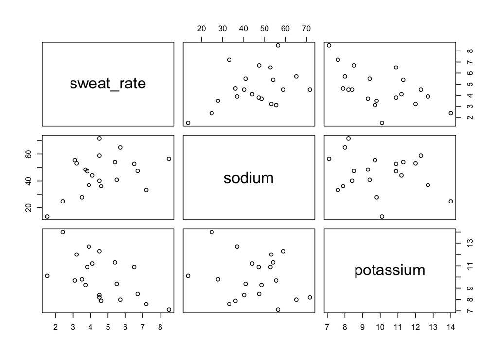

```r
pairs(X2)
```

We observe that these Q-Q plots are all approximate straight lines and scatter plot for pairs have approximate elliptical shapes. Therefore, we conclude the multivariate normal assumption is reasonable.

## 5.18

Import data

```r
X3 <- read.table("T5-2.DAT", col.names = c('social_sci_hist',
                                           "verbal", "science"))
meanX3 <- colMeans(X3)
n3 <- nrow(X3)
p3 <- ncol(X3)
covX3 <- cov(X3)
```

Test hypothesis at the $\alpha=.05$ level of significance

```r
alpha3 <- .05
threshold <- fscale(p3, n3, alpha3) # fscale defined as before
mu3 <- c(500, 50, 30)
dev <- mu3 - meanX3 # deviation
squared_dist3 <- as.numeric(dev %*% solve(covX3, dev))
threshold
```

```
## [1] 0.09578716
```

```r
squared_dist3
```

```
## [1] 2.566784
```

```r
squared_dist3 < threshold
```

```
## [1] FALSE
```

By calculations we find $\mu = [500, 50, 30]$ lies out of the 95% confidence region. Thus, we reject the null hypothesis at the $\alpha=.05$ level of significance.

Compute axes of the 95% confidence ellipsoid for $\mu$

```r
eigensys3 <- eigen(covX3)
eigensys3$vectors # eigenvectors, i.e. axes of the ellipsoid
```

```
##            [,1]         [,2]         [,3]
## [1,] 0.99390539  0.103731534 -0.037307396
## [2,] 0.10344339 -0.994589227 -0.009577815
## [3,] 0.03809906 -0.005660238  0.999257936
```

```r
axesLength <- sqrt(eigensys3$values * fscale(p3, n3, alpha3))
axesLength # length of axes
```

```
## [1] 23.729998  2.472768  1.182500
```

Construct Q-Q plots for each marginal distributions

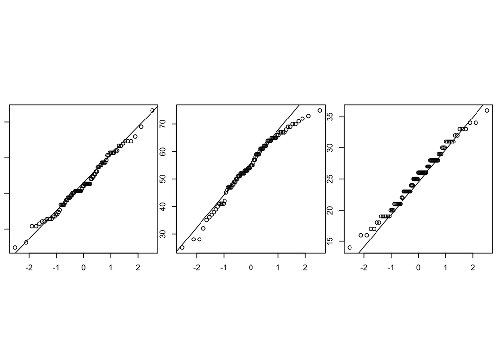

```r
layout(matrix(1:3, nrow = 1, byrow = TRUE), respect = TRUE)
par(mar = rep.int(1, 4))
rqs <- sapply(X3, plotqq) # Q-Q plot
```

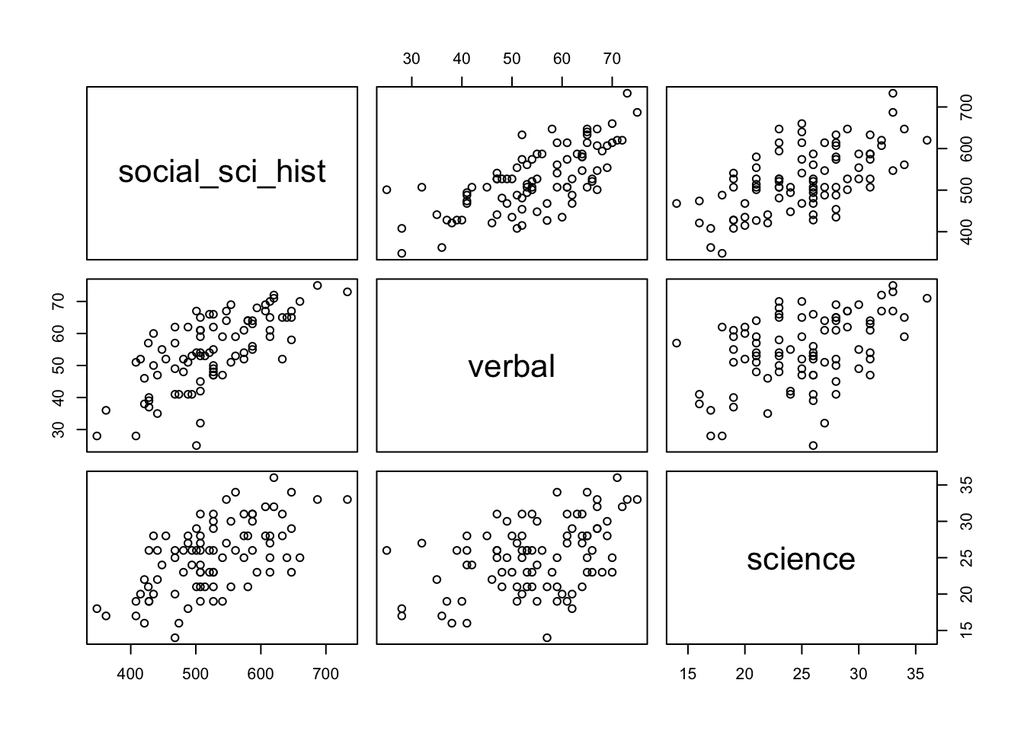

```r
pairs(X3) # pairwise scatter plot
```

We observe that these Q-Q plots are all approximate straight lines and scatter plot for pairs have approximate elliptical shapes. Therefore, we conclude the multivariate normal assumption is reasonable.